# Task 2 - Palmetto Species Differentiation Using Binary Logistic Regression

Logan Ossentjuk

2/1/2022

# Overview

This report investigates data collected between 1981 and 2017 on the survival and growth rates of palmetto species (*Serenoa repens* and *Sabal etonia*) at the Archbold Biological Station in South Florida. A binary logistic regression analysis is completed based upon features key to palmetto growth. These key variables are found via data visualization and examination. AIC analysis 10-fold cross validation are then performed. The models are trained on the entire data set and results are used to determine which is more comprehensive and accurate.

**Data citation:** Abrahamson, W.G. 2019. Survival, growth and biomass estimates of two dominant palmetto species of south-central Florida from 1981 - 2017, ongoing at 5-year intervals ver 1. Environmental Data Initiative. https://doi.org/10.6073/pasta/f2f96ec76fbbd4b9db431c79a770c4d5 Get the data: palmetto.csv **More information and metadata:** https://portal.edirepository.org/nis/metadataviewer?packageid=edi.317.1

```r
knitr::opts_chunk$set(echo = TRUE, message = FALSE, warning = FALSE)
library(here)
library(tidyverse)
library(janitor)
library(patchwork)
library(lubridate)
library(kableExtra)
library(ggbeeswarm)
library(GGally)
library(jtools)
library(caret)
library(AICcmodavg)
library(broom)
```

## Data Visualization:

### Performed to determine variables of importance

```r
###Wrangling and subsetting
palmetto <- read.csv(here('data', 'palmetto.csv')) %>%
  clean_names()

palmetto_exp <- palmetto %>%
  mutate(species = as.character(species)) %>%
  select(height, length, width, green_lvs, species) %>%
  drop_na() %>%
  ggpairs(aes(color = species))
#palmetto_sub

palmetto_sub <-palmetto %>%
  mutate(species = as.factor(species)) %>%
  select(height, length, width, green_lvs, species) %>%
  drop_na()
```

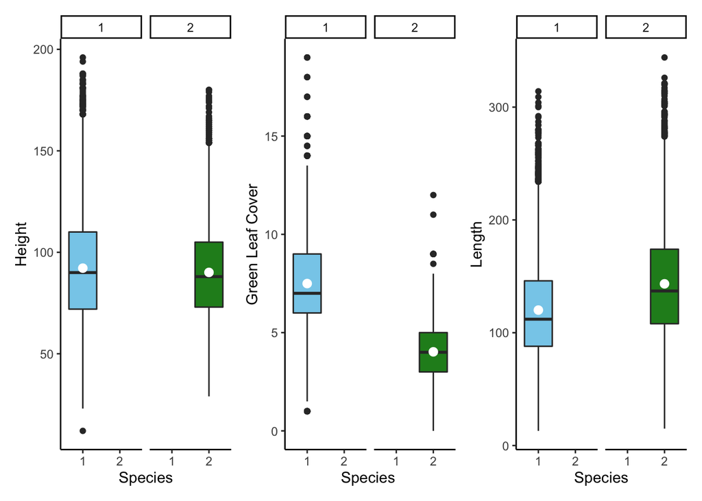

```r
### Figures

p1 <- ggplot(data = palmetto_sub, aes (x = species, y = height)) +
  geom_boxplot(aes(fill = species, width = 0.2)) +
   stat_summary(fun=mean,
               geom="point",
               shape=20,
               size=4,
               color="white",
               fill="red") +
   scale_fill_manual(values = c("skyblue", "forestgreen"),
                    name = "Species") +
  facet_wrap(~species) +
  theme_classic() +
  theme(legend.position = "none") +
  labs( x = "Species",
        y = "Height")

p2 <- ggplot(data = palmetto_sub, aes (x = species, y = green_lvs)) +
  geom_boxplot(aes(fill = species, width = 0.2)) +
  stat_summary(fun=mean,
               geom="point",
               shape=20,
               size=4,
               color="white",
               fill="red") +
  scale_fill_manual(values = c("skyblue","forestgreen"),
                     name = "Species") +
   facet_wrap(~species) +
   theme_classic() +
  theme(legend.position = "none") +
  labs( x = "Species ",
        y = "Green Leaf Cover")

p3 <- ggplot(data = palmetto_sub, aes(x = species, y = length)) +
  geom_boxplot(aes(fill = species, width = 0.2)) +
  stat_summary(fun=mean,
               geom="point",
               shape=20,
               size=4,
               color="white",
               fill="red") +
   scale_fill_manual(values = c("skyblue", "forestgreen"),
                    name = "Species") +
  facet_wrap(~species) +
  theme_classic() +
  theme(legend.position = "none") +
  labs( x = "Species",
        y = "Length")

p1 | p2 | p3
```

**Figure 1:** compares the ability for three measured variables on Palmetto canopy (*Height, Green Leaf Percent, Length*) to differentiate between two species. Species 1 (*Serenoa repens*), Species 2 (*Sabal etonia*).

**Takeaway:** Given the above figure, green leaf cover and canopy length are the best predictor variables for differentiating between species. The displayed differences median (black line), mean (white dot) and spread are most significant between species for these variables. Plant height is shown to be nearly identical between species and is therefore a poor differentiator.

#### Binary Logistic Regression

```r
binary_palmetto <- palmetto_sub %>%
  mutate( species = case_when(species %in% c('1') ~ 'Serenoa repens',
                              species %in% c('2') ~ 'Sabal etonia')) %>%
  filter(species %in% c('Serenoa repens', 'Sabal etonia')) %>%
  mutate(species = fct_drop(species)) %>%
  #select(-island, -year) %>%
  drop_na()
```

```r
### Model 1

f1 <- species ~ height + length + width + green_lvs

palmetto_blr1 <- glm(formula = f1,
                    data = binary_palmetto,
                    family = 'binomial')

### See results

#palmetto_blr1

#summary(palmetto_blr1)

blr1_tidy1 <- broom::tidy(palmetto_blr1)

blr1_fitted <- palmetto_blr1 %>%
  broom::augment(type.predict = 'response')

### Model 2
f2 <- species ~ height + width + green_lvs

palmetto_blr2 <- glm(formula = f2,
                    data = binary_palmetto,
                    family = 'binomial')

#palmetto_blr2

#summary(palmetto_blr2)

blr1_tidy2 <- broom::tidy(palmetto_blr2)

blr2_fitted <- palmetto_blr2 %>%
  broom::augment(type.predict = 'response')
```

## Model Training and Selection

*Model 1:* Determines Palmetto species based on height canopy length, canopy width and green leaf cover

*Model 2:* Determines Palmetto species based on height, canopy width and green leaf cover

#### AIC values

```r
palmetto_aic <- AICcmodavg::aictab(list(palmetto_blr1, palmetto_blr2))
#Mod 1: 5194.567
#Mod 2: 5194.567
```

#### 10-fold cross validation, use prediction accuracy as our metric

```r
set.seed(333)

tr_ctrl <- trainControl(method = 'repeatedcv', number = 10, repeats = 10)

### Train the model

model1 <- train(f1, data = palmetto_sub,
                method = 'glm', family = 'binomial',
                trControl = tr_ctrl)
# model1
# accuracy: 0.9168912

model2 <- train(f2, data = palmetto_sub,
                method = 'glm', family = 'binomial',
                trControl = tr_ctrl)
# model2
# accuracy: 0.8988258
```

*Model 1 AIC:* 5194.57

*Model 2 AIC:* 5987.48

**Results:** Model 1 superiorly selects the correct Palmetto species given inputs (**AIC:** 5194.57, **Accuracy** = 92%) as compared to Model 2 (**AIC:** 5987.48, **Accuracy** = 90%, **Delta AIC** = 792.9). Given these differences Model 1 is clearly the superior option.

```r
palmetto_blr1_tidy <- broom::tidy(palmetto_blr1) %>%
  mutate(term = case_when(
         term == "(Intercept)" ~ "Intercept",
         term == "height" ~ "Height",
         term == "length" ~ "Length",
         term == "width" ~ "Width",
         term == "green_lvs" ~ "Green Leaf Cover"))

palmetto_blr1_tidy %>%
  mutate(p.value = ifelse(p.value < .005, paste("<0.005"))) %>%
  kable(digits = 3, col.names = c('Term', 'Estimate', 'Standard Error', 'Statistic', 'P Value'), caption = '<center/>Table 1: Summary of variable coeffiencents and their statistical significance. All p values <0.001.</center>') %>%
          kable_classic(bootstrap_options = 'striped', full_width = FALSE)
```

Table 1: Summary of variable coeffiencents and their statistical significance. All p values <0.001.

| Term | Estimate | Standard Error | Statistic | P Value |
| --- | --- | --- | --- | --- |
| Intercept | -3.227 | 0.142 | -22.712 | <0.005 |
| Height | 0.029 | 0.002 | 12.670 | <0.005 |
| Length | -0.046 | 0.002 | -24.556 | <0.005 |
| Width | -0.039 | 0.002 | -18.782 | <0.005 |
| Green Leaf Cover | 1.908 | 0.039 | 49.107 | <0.005 |

### Model 1 Prediction Success Rate

```r
palmetto_blr1_fitted <- palmetto_blr1 %>%
  augment(type.predict = "response") %>%
  mutate(classify_species = case_when(
    .fitted > .5 ~ "Serenoa repens",
    .fitted < .5 ~ "Sabal etonia"),
  success = case_when(
    species == classify_species ~ 'yes',
    species != classify_species ~ 'no'
  ))

sum_success <- palmetto_blr1_fitted %>%
  group_by(species, success) %>%
  summarize(count = n()) %>%
  pivot_wider(names_from = success,
              values_from = count) %>%
  mutate(percent_correct = yes/(no+yes) *100)

sum_success %>%
  kable(col.names = c('Species',
                      'Incorrect',
                      'Correct',
                      '%Correctly Classified'),
        caption = '**Table 2: Model 1 success rate at differentiating Palmetto species after trained on entire dataset') %>%
  kable_classic(full_width = FALSE)
```

**Table 2: Model 1 success rate at differentiating Palmetto species after trained on entire dataset

| Species | Incorrect | Correct | %Correctly Classified |
| --- | --- | --- | --- |
| Sabal etonia | 454 | 5701 | 92.62388 |
| Serenoa repens | 564 | 5548 | 90.77225 |

**Data citation:** Abrahamson, W.G. 2019. Survival, growth and biomass estimates of two dominant palmetto species of south-central Florida from 1981 - 2017, ongoing at 5-year intervals ver 1. Environmental Data Initiative. https://doi.org/10.6073/pasta/f2f96ec76fbbd4b9db431c79a770c4d5 Get the data: palmetto.csv